# Homework 6

Stat 452

Author

Suweda and Anna

For this assignment, I want you to work together with a partner.

## Research Question

1. Based on your previous work with this data set, including your literature search, come up with one research question to address as a team.

ANSWER: Does the reasoning training intervention positively affect the reasoning over time, controlling for baseline age, years of education, and gender?

2. Based on your previous work with this data set, including your literature search, come up with a mean model (x’s and their functional format) that addresses your research question (accounting for potential confounders).

$$

$$

## Longitudinal Models

Let’s do a quick review:

**Marginal Models** For models fit with GEE, we need to specify a working correlation structure, but the robust standard errors are valid even if we get that structure wrong.

**Mixed Effects Models** We can write a linear mixed effects model in terms of our outcome vector,

$$\mathbf{Y}_{i} = \mathbf{X}_{i}\boldsymbol\beta + \mathbf{Z}_i\mathbf{b}_i + \boldsymbol\epsilon_i$$

$$= \text{Fixed effects} + \text{Random effects} + \text{Error}$$

where $\mathbf{X}_i$ is the design matrix for the fixed effects, $\mathbf{Z}_i$ is the design matrix for the random effects (a subset of columns of $\mathbf{X}_i$), $\boldsymbol\epsilon_i\sim N(0,\boldsymbol\Sigma)$, $\mathbf{b}_i\sim N(0,\mathbf{G})$, and $\mathbf{b}_i$ and $\boldsymbol\epsilon_i$ are independent.

Thus,

$$\mathbf{Y}_{i}\sim \mathcal{N}(\mathbf{X}_{i}\boldsymbol\beta,\mathbf{Z}_i\mathbf{G}\mathbf{Z}_i^T + \boldsymbol\Sigma)$$

BEFORE YOU BEGIN: Decide whether you and your partner want to use Mixed Effects or GEE models. You’ll use the type of model throughout.

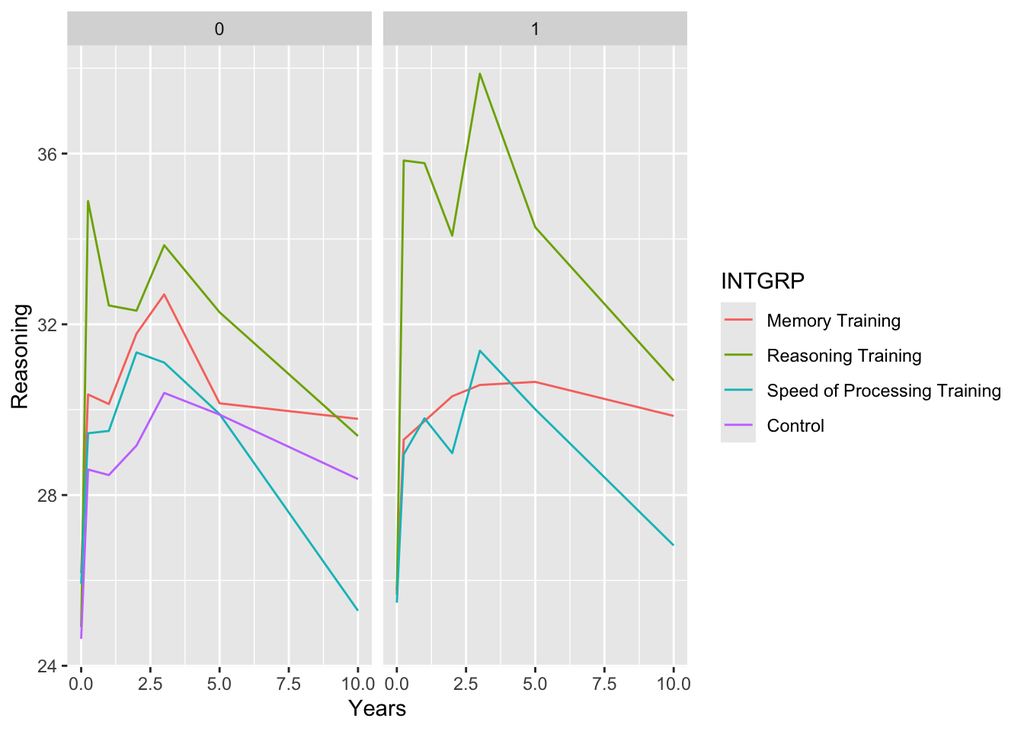

```r
#We will use mixed effects models
source('cleaning_active.R')
activeLong %>%
  group_by(Years, INTGRP, BOOSTER) %>%
  summarize(Reasoning = mean(Reasoning,na.rm=TRUE)) %>%
  ggplot(aes(x = Years,  y =Reasoning, color = INTGRP)) +
  geom_line() + facet_wrap(~BOOSTER)
```

3. Come up with at least 2 candidate models (different correlation structures) that you want to fit.
- GEE: consider working correlation structures, describe them in words, and then fit them with `geeM::geem()`.
- Mixed Effects: start with random intercept and consider which coef could be random, describe them in words, and then fit them with `lme4::lmer()`.

```r
library(geeM)
library(lme4)

activeLong_new <- activeLong %>%
  group_by(AID) %>%
  mutate(Baseline_Reasoning = Reasoning[Years == 0]) |>
  filter(
    INTGRP %in% c("Reasoning Training", "Control"),
    Years <= 5
    ) |>
  mutate(years_more3 = if_else(Years>=3, 1, 0)) |>
  drop_na(Reasoning, Years, YRSEDUC, AgeAtBaseline, INTGRP, GENDER)
```

ANSWER:

- Model 1: The model estimates the average change in reasoning scores over time (assuming different slopes before and after 3 years), controlling for years of education, age at baseline, and gender. It allows participants to have random intercepts (reasoning baselines).

```r
rsn_mod1 <-  lmer(
  Reasoning ~ INTGRP*years_more3*Years + YRSEDUC + AgeAtBaseline + GENDER + (1|AID),
  data = activeLong_new,
  REML = FALSE)

rsn_mod1 %>% summary()
```

```
Linear mixed model fit by maximum likelihood  ['lmerMod']
Formula: Reasoning ~ INTGRP * years_more3 * Years + YRSEDUC + AgeAtBaseline +
    GENDER + (1 | AID)
   Data: activeLong_new

     AIC      BIC   logLik deviance df.resid
 41326.8  41414.4 -20650.4  41300.8     6217

Scaled residuals:
    Min      1Q  Median      3Q     Max
-4.2135 -0.5451 -0.0095  0.5671  4.4366

Random effects:
 Groups   Name        Variance Std.Dev.
 AID      (Intercept) 106.03   10.30
 Residual              22.75    4.77
Number of obs: 6230, groups:  AID, 1395

Fixed effects:
                                Estimate Std. Error t value
(Intercept)                     55.71227    4.29423  12.974
INTGRPControl                   -2.78616    0.58618  -4.753
years_more3                      9.62604    0.68532  14.046
Years                            1.74684    0.13733  12.720
YRSEDUC                          1.78173    0.10795  16.505
AgeAtBaseline                   -0.69880    0.04856 -14.391
GENDER                           0.57379    0.67299   0.853
INTGRPControl:years_more3       -4.47174    0.98786  -4.527
INTGRPControl:Years             -0.82762    0.19446  -4.256
years_more3:Years               -3.53408    0.21476 -16.456
INTGRPControl:years_more3:Years  1.62410    0.30797   5.274

Correlation of Fixed Effects:
            (Intr) INTGRPCn yrs_m3 Years  YRSEDU AgAtBs GENDER INTGRPCn:_3
INTGRPCntrl -0.055
years_more3 -0.008  0.045
Years       -0.026  0.148    0.154
YRSEDUC     -0.468  0.026    0.000 -0.002
AgeAtBaseln -0.874 -0.040    0.002  0.008  0.089
GENDER      -0.381  0.040    0.000  0.000  0.197  0.044
INTGRPCn:_3  0.005 -0.063   -0.694 -0.107  0.000 -0.001  0.001
INTGRPCnt:Y  0.018 -0.210   -0.109 -0.706 -0.003 -0.003 -0.002  0.152
yrs_mr3:Yrs  0.015 -0.095   -0.825 -0.639  0.002 -0.003  0.000  0.572
INTGRPC:_3: -0.011  0.132    0.575  0.446  0.000  0.003 -0.001 -0.829
            INTGRPC:Y yr_3:Y
INTGRPCntrl
years_more3
Years
YRSEDUC
AgeAtBaseln
GENDER
INTGRPCn:_3
INTGRPCnt:Y
yrs_mr3:Yrs  0.451
INTGRPC:_3: -0.631    -0.697
```

```r
rsn_mod2 <-  lmer(
  Reasoning ~ INTGRP*years_more3*Years + YRSEDUC + AgeAtBaseline + GENDER + (Years | AID),
  data = activeLong_new,
  REML = FALSE)

rsn_mod2 %>% summary()
```

```
Linear mixed model fit by maximum likelihood  ['lmerMod']
Formula: Reasoning ~ INTGRP * years_more3 * Years + YRSEDUC + AgeAtBaseline +
    GENDER + (Years | AID)
   Data: activeLong_new

     AIC      BIC   logLik deviance df.resid
 41308.8  41409.9 -20639.4  41278.8     6215

Scaled residuals:
    Min      1Q  Median      3Q     Max
-4.0073 -0.5523 -0.0145  0.5651  4.4645

Random effects:
 Groups   Name        Variance  Std.Dev. Corr
 AID      (Intercept) 101.19796 10.0597
          Years         0.08914  0.2986  0.59
 Residual              22.48147  4.7415
Number of obs: 6230, groups:  AID, 1395

Fixed effects:
                                Estimate Std. Error t value
(Intercept)                     53.61521    4.25667  12.596
INTGRPControl                   -2.80786    0.57382  -4.893
years_more3                      9.71039    0.68244  14.229
Years                            1.72944    0.13737  12.589
YRSEDUC                          1.79407    0.10708  16.754
AgeAtBaseline                   -0.66870    0.04814 -13.890
GENDER                           0.41786    0.66767   0.626
INTGRPControl:years_more3       -4.45861    0.98407  -4.531
INTGRPControl:Years             -0.82520    0.19454  -4.242
years_more3:Years               -3.57495    0.21387 -16.715
INTGRPControl:years_more3:Years  1.62552    0.30680   5.298

Correlation of Fixed Effects:
            (Intr) INTGRPCn yrs_m3 Years  YRSEDU AgAtBs GENDER INTGRPCn:_3
INTGRPCntrl -0.054
years_more3 -0.010  0.046
Years       -0.020  0.117    0.153
YRSEDUC     -0.468  0.027    0.000 -0.002
AgeAtBaseln -0.874 -0.041    0.005  0.005  0.089
GENDER      -0.381  0.041    0.000  0.000  0.196  0.044
INTGRPCn:_3  0.006 -0.064   -0.693 -0.106 -0.002 -0.001 -0.001
INTGRPCnt:Y  0.014 -0.166   -0.108 -0.706 -0.002 -0.002 -0.002  0.151
yrs_mr3:Yrs  0.018 -0.096   -0.825 -0.635  0.001 -0.007  0.000  0.572
INTGRPC:_3: -0.012  0.134    0.575  0.443  0.002  0.002  0.002 -0.829
            INTGRPC:Y yr_3:Y
INTGRPCntrl
years_more3
Years
YRSEDUC
AgeAtBaseln
GENDER
INTGRPCn:_3
INTGRPCnt:Y
yrs_mr3:Yrs  0.449
INTGRPC:_3: -0.627    -0.697
```

4. Write bullet points about what you learn about your outcome, research question, and the modeling process from fitting these two models.

ANSWER:

## Inference

### Hypothesis Testing for Fixed Coefficients (one at a time)

We can use this inference tool for either GEE or Mixed Effects Models.

We can test whether $\beta_k=0$ for some $k$.

In marginal models (GEE), the estimated covariance matrix for $\hat{\boldsymbol\beta}$ is given by the robust sandwich estimator. The Robust SE for $\hat{\beta}_k$ is the square rooted values of the diagonal of this matrix corresponding to $\hat{\beta}_k$. This is what is reported in the summary output as Robust SE.

In mixed effects models, the estimated covariance matrix for $\hat{\boldsymbol\beta}$ is based on assuming the random effects are correct.

To test the hypothesis $H_0: \beta_k=0$ vs. $H_A: \beta_k\not=0$, we can calculate a z-statistic,

$$z = \frac{\hat{\beta}_k}{SE(\hat{\beta}_k)}$$

With GEE, the `geem()` function provides z statistics (labeled as `wald`) and associated p-values for testing $H_0: \beta_k= 0$. These p-values come from a Normal distribution because we know that is the asymptotic (as the sample size, $n\rightarrow \infty$) distribution for these estimates.

With mixed effects, the `lmer()` function provides z statistics (labeled as `t-value`) for the fixed effects (but not the p-values) for testing $H_0: \beta_k= 0$. We could compare the t-values to the cut off of +/-2 because we know that the asymptotic (as the sample size, $n\rightarrow \infty$) distribution for these estimates is Normal if the model is correct.

```r
#gee_mod1 %>% summary()
#lmer_mod1 %>% summary()
rsn_mod1 %>% summary()
```

```
Linear mixed model fit by maximum likelihood  ['lmerMod']
Formula: Reasoning ~ INTGRP * years_more3 * Years + YRSEDUC + AgeAtBaseline +
    GENDER + (1 | AID)
   Data: activeLong_new

     AIC      BIC   logLik deviance df.resid
 41326.8  41414.4 -20650.4  41300.8     6217

Scaled residuals:
    Min      1Q  Median      3Q     Max
-4.2135 -0.5451 -0.0095  0.5671  4.4366

Random effects:
 Groups   Name        Variance Std.Dev.
 AID      (Intercept) 106.03   10.30
 Residual              22.75    4.77
Number of obs: 6230, groups:  AID, 1395

Fixed effects:
                                Estimate Std. Error t value
(Intercept)                     55.71227    4.29423  12.974
INTGRPControl                   -2.78616    0.58618  -4.753
years_more3                      9.62604    0.68532  14.046
Years                            1.74684    0.13733  12.720
YRSEDUC                          1.78173    0.10795  16.505
AgeAtBaseline                   -0.69880    0.04856 -14.391
GENDER                           0.57379    0.67299   0.853
INTGRPControl:years_more3       -4.47174    0.98786  -4.527
INTGRPControl:Years             -0.82762    0.19446  -4.256
years_more3:Years               -3.53408    0.21476 -16.456
INTGRPControl:years_more3:Years  1.62410    0.30797   5.274

Correlation of Fixed Effects:
            (Intr) INTGRPCn yrs_m3 Years  YRSEDU AgAtBs GENDER INTGRPCn:_3
INTGRPCntrl -0.055
years_more3 -0.008  0.045
Years       -0.026  0.148    0.154
YRSEDUC     -0.468  0.026    0.000 -0.002
AgeAtBaseln -0.874 -0.040    0.002  0.008  0.089
GENDER      -0.381  0.040    0.000  0.000  0.197  0.044
INTGRPCn:_3  0.005 -0.063   -0.694 -0.107  0.000 -0.001  0.001
INTGRPCnt:Y  0.018 -0.210   -0.109 -0.706 -0.003 -0.003 -0.002  0.152
yrs_mr3:Yrs  0.015 -0.095   -0.825 -0.639  0.002 -0.003  0.000  0.572
INTGRPC:_3: -0.011  0.132    0.575  0.446  0.000  0.003 -0.001 -0.829
            INTGRPC:Y yr_3:Y
INTGRPCntrl
years_more3
Years
YRSEDUC
AgeAtBaseln
GENDER
INTGRPCn:_3
INTGRPCnt:Y
yrs_mr3:Yrs  0.451
INTGRPC:_3: -0.631    -0.697
```

```r
rsn_mod2 %>% summary()
```

```
Linear mixed model fit by maximum likelihood  ['lmerMod']
Formula: Reasoning ~ INTGRP * years_more3 * Years + YRSEDUC + AgeAtBaseline +
    GENDER + (Years | AID)
   Data: activeLong_new

     AIC      BIC   logLik deviance df.resid
 41308.8  41409.9 -20639.4  41278.8     6215

Scaled residuals:
    Min      1Q  Median      3Q     Max
-4.0073 -0.5523 -0.0145  0.5651  4.4645

Random effects:
 Groups   Name        Variance  Std.Dev. Corr
 AID      (Intercept) 101.19796 10.0597
          Years         0.08914  0.2986  0.59
 Residual              22.48147  4.7415
Number of obs: 6230, groups:  AID, 1395

Fixed effects:
                                Estimate Std. Error t value
(Intercept)                     53.61521    4.25667  12.596
INTGRPControl                   -2.80786    0.57382  -4.893
years_more3                      9.71039    0.68244  14.229
Years                            1.72944    0.13737  12.589
YRSEDUC                          1.79407    0.10708  16.754
AgeAtBaseline                   -0.66870    0.04814 -13.890
GENDER                           0.41786    0.66767   0.626
INTGRPControl:years_more3       -4.45861    0.98407  -4.531
INTGRPControl:Years             -0.82520    0.19454  -4.242
years_more3:Years               -3.57495    0.21387 -16.715
INTGRPControl:years_more3:Years  1.62552    0.30680   5.298

Correlation of Fixed Effects:
            (Intr) INTGRPCn yrs_m3 Years  YRSEDU AgAtBs GENDER INTGRPCn:_3
INTGRPCntrl -0.054
years_more3 -0.010  0.046
Years       -0.020  0.117    0.153
YRSEDUC     -0.468  0.027    0.000 -0.002
AgeAtBaseln -0.874 -0.041    0.005  0.005  0.089
GENDER      -0.381  0.041    0.000  0.000  0.196  0.044
INTGRPCn:_3  0.006 -0.064   -0.693 -0.106 -0.002 -0.001 -0.001
INTGRPCnt:Y  0.014 -0.166   -0.108 -0.706 -0.002 -0.002 -0.002  0.151
yrs_mr3:Yrs  0.018 -0.096   -0.825 -0.635  0.001 -0.007  0.000  0.572
INTGRPC:_3: -0.012  0.134    0.575  0.443  0.002  0.002  0.002 -0.829
            INTGRPC:Y yr_3:Y
INTGRPCntrl
years_more3
Years
YRSEDUC
AgeAtBaseln
GENDER
INTGRPCn:_3
INTGRPCnt:Y
yrs_mr3:Yrs  0.449
INTGRPC:_3: -0.627    -0.697
```

5. Looking back on the models you fit, what do you conclude about the fixed coefficients? Do you think they are zero or not?

ANSWER: Across all our models, the only coefficient that has an absolute t-value lower that 2 is gender, meaning we do not have evidence that the fixed effect of gender has a statistically significant effect on reasoning scores.

### Diagnostics

For any model with a quantitative outcome, we should check to see if the residuals have no pattern.

6. Create a residual plot for your best model so far, plotting the residuals on the y-axis against a quantitative x-variable. Comment on the residual plot. See some example code below.

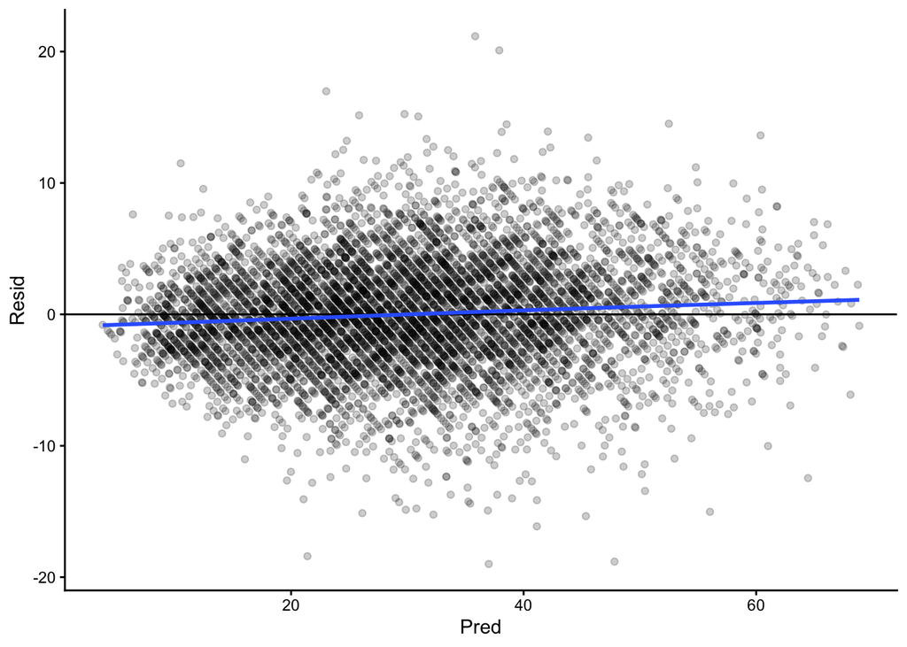

```r
# Residuals = Obs - Predicted
#second line removes NA for no errors
activeLong_new %>%
  ungroup() |>
  drop_na(Reasoning, Years, YRSEDUC, AgeAtBaseline, INTGRP, GENDER) %>%
  mutate(Pred = predict(rsn_mod2, newdata = .)) %>% #replace mod with your chosen model
  mutate(Resid = Reasoning - Pred) %>%  #replace y with your outcome
  ggplot(aes(x = Pred, y = Resid)) +  # you can replace Pred with a quantitative x
  geom_point(alpha = .2) +
  geom_hline(yintercept = 0) +
  geom_smooth(se = FALSE) +
  theme_classic()
```

7. Considering all of the choices you need to make, make an argument for one final model using a variety of tools in 3-5 sentences.

```r
anova(rsn_mod1,rsn_mod2 ) #same fixed effects, different random effects
```

```
Data: activeLong_new
Models:
rsn_mod1: Reasoning ~ INTGRP * years_more3 * Years + YRSEDUC + AgeAtBaseline + GENDER + (1 | AID)
rsn_mod2: Reasoning ~ INTGRP * years_more3 * Years + YRSEDUC + AgeAtBaseline + GENDER + (Years | AID)
         npar   AIC   BIC logLik deviance Chisq Df Pr(>Chisq)
rsn_mod1   13 41327 41414 -20650    41301
rsn_mod2   15 41309 41410 -20639    41279 21.98  2  1.687e-05 ***
---
Signif. codes:  0 '***' 0.001 '**' 0.01 '*' 0.05 '.' 0.1 ' ' 1
```

```r
#h0: smaller model is correct


#fixed
rsn_mod2_nested <-  lmer(
  Reasoning ~ INTGRP * years_more3 * Years + YRSEDUC + (Years | AID),
  data = activeLong_new,
  REML = FALSE)
anova(rsn_mod2_nested, rsn_mod2)
```

```
Data: activeLong_new
Models:
rsn_mod2_nested: Reasoning ~ INTGRP * years_more3 * Years + YRSEDUC + (Years | AID)
rsn_mod2: Reasoning ~ INTGRP * years_more3 * Years + YRSEDUC + AgeAtBaseline + GENDER + (Years | AID)
                npar   AIC   BIC logLik deviance  Chisq Df Pr(>Chisq)
rsn_mod2_nested   13 41484 41571 -20729    41458
rsn_mod2          15 41309 41410 -20639    41279 178.71  2  < 2.2e-16 ***
---
Signif. codes:  0 '***' 0.001 '**' 0.01 '*' 0.05 '.' 0.1 ' ' 1
```

```r
#random
rsn_mod2_nested2 <- lmer(
  Reasoning ~INTGRP * years_more3 * Years +  AgeAtBaseline + GENDER + (Years | AID),
  data = activeLong_new,
  REML = TRUE
)


anova(rsn_mod2_nested2, rsn_mod2)
```

```
refitting model(s) with ML (instead of REML)
```

```
Data: activeLong_new
Models:
rsn_mod2_nested2: Reasoning ~ INTGRP * years_more3 * Years + AgeAtBaseline + GENDER + (Years | AID)
rsn_mod2: Reasoning ~ INTGRP * years_more3 * Years + YRSEDUC + AgeAtBaseline + GENDER + (Years | AID)
                 npar   AIC   BIC logLik deviance  Chisq Df Pr(>Chisq)
rsn_mod2_nested2   14 41563 41657 -20767    41535
rsn_mod2           15 41309 41410 -20639    41279 255.71  1  < 2.2e-16 ***
---
Signif. codes:  0 '***' 0.001 '**' 0.01 '*' 0.05 '.' 0.1 ' ' 1
```

```r
rsn_mod2 <-  lmer(
  Reasoning ~ INTGRP*years_more3*Years + YRSEDUC + AgeAtBaseline + GENDER + (Years | AID),
  data = activeLong_new,
  REML = TRUE)

rsn_mod2 %>% summary()
```

```
Linear mixed model fit by REML ['lmerMod']
Formula: Reasoning ~ INTGRP * years_more3 * Years + YRSEDUC + AgeAtBaseline +
    GENDER + (Years | AID)
   Data: activeLong_new

REML criterion at convergence: 41295

Scaled residuals:
    Min      1Q  Median      3Q     Max
-3.9990 -0.5519 -0.0144  0.5645  4.4604

Random effects:
 Groups   Name        Variance  Std.Dev. Corr
 AID      (Intercept) 101.58780 10.0791
          Years         0.09135  0.3022  0.58
 Residual              22.50331  4.7438
Number of obs: 6230, groups:  AID, 1395

Fixed effects:
                                Estimate Std. Error t value
(Intercept)                     53.61405    4.26431  12.573
INTGRPControl                   -2.80782    0.57483  -4.885
years_more3                      9.71008    0.68279  14.221
Years                            1.72932    0.13746  12.581
YRSEDUC                          1.79408    0.10727  16.724
AgeAtBaseline                   -0.66869    0.04823 -13.865
GENDER                           0.41782    0.66887   0.625
INTGRPControl:years_more3       -4.45846    0.98458  -4.528
INTGRPControl:Years             -0.82521    0.19465  -4.239
years_more3:Years               -3.57480    0.21399 -16.706
INTGRPControl:years_more3:Years  1.62548    0.30697   5.295

Correlation of Fixed Effects:
            (Intr) INTGRPCn yrs_m3 Years  YRSEDU AgAtBs GENDER INTGRPCn:_3
INTGRPCntrl -0.054
years_more3 -0.010  0.045
Years       -0.020  0.117    0.153
YRSEDUC     -0.468  0.027    0.000 -0.002
AgeAtBaseln -0.874 -0.041    0.005  0.005  0.089
GENDER      -0.381  0.041    0.000  0.000  0.196  0.044
INTGRPCn:_3  0.006 -0.064   -0.693 -0.106 -0.002 -0.001 -0.001
INTGRPCnt:Y  0.014 -0.166   -0.108 -0.706 -0.002 -0.002 -0.002  0.151
yrs_mr3:Yrs  0.018 -0.096   -0.825 -0.635  0.001 -0.007  0.000  0.572
INTGRPC:_3: -0.012  0.134    0.575  0.443  0.002  0.002  0.002 -0.829
            INTGRPC:Y yr_3:Y
INTGRPCntrl
years_more3
Years
YRSEDUC
AgeAtBaseln
GENDER
INTGRPCn:_3
INTGRPCnt:Y
yrs_mr3:Yrs  0.449
INTGRPC:_3: -0.627    -0.697
```

8. Using that final model, what do you conclude about your original research question about brain training among the elderly?

ANSWER: Our final model estimates that overall, holding all else constant, reasoning training was associated with higher reasoning scores when compared to the control. During the first three years, the scores of those who received reasoning training increased at a faster rate than those who did not receive the intervention. However, after three years, the scores also decreased at a faster rate, suggesting that while there is evidence to show that reasoning training has short term benefits, those who received the intervention may return just as quickly to the baseline.

## Done!

- Render your homework.
- Make sure the html file looks like you want it.
- Submit your assignment as instructed.